# —— 基于文本挖掘的电商产品评论数据情感分析 ——

[output not shown]

### 2.框架

[output not shown]

## 一、导包

```python
import os #获取文件/文档信息路径的获取
import numpy as np #完成基础数据计算
import pandas as pd #数据挖掘，数据分析、数据清洗功能
import matplotlib.pyplot as plt #绘制图形
from  matplotlib.pylab import style  #自定义图表风格
%pip install re
import re #数据处理时候的正则表达式
%pip install seaborn
import seaborn as sns #数据可视化库，封装在matplotlib库上的可视化库
import jieba #中文分词用的
import jieba.posseg as psg #jieba分词时用posseg进行词性标注
import wordcloud  #绘制词云图
from wordcloud import WordCloud,ImageColorGenerator #词云对象库


#以下这个是可以一行多个输出
from IPython.core.interactiveshell import InteractiveShell
InteractiveShell.ast_node_interactivity = "all"
```

[output not shown]

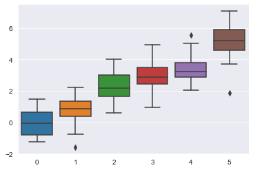

```python
#了解seaborn库
sns.set_style('darkgrid')
data=np.random.normal(size=(20,6))+np.arange(6)
sns.boxplot(data=data)
```

## 二、 导入商品评论数据并查看数据信息

```python
raw_data=pd.read_csv('./reviews.csv')
raw_data.shape #查看表结构
```

```
(2000, 5)
```

```python
raw_data.info()#数据框结构
raw_data.head()
```

```
<class 'pandas.core.frame.DataFrame'>
RangeIndex: 2000 entries, 0 to 1999
Data columns (total 5 columns):
 #   Column         Non-Null Count  Dtype
---  ------         --------------  -----
 0   content        2000 non-null   object
 1   creationTime   2000 non-null   object
 2   nickname       2000 non-null   object
 3   referenceName  2000 non-null   object
 4   content_type   2000 non-null   object
dtypes: object(5)
memory usage: 78.2+ KB
```

|  | content | creationTime | nickname | referenceName | content_type |
| --- | --- | --- | --- | --- | --- |
| 0 | 东西收到这么久，都忘了去好评，美的大品牌，值得信赖，东西整体来看，个人感觉还不错，没有出现什... | 2017-04-17 13:01:54 | 鑫***辰 | 美的（Midea）60升预约洗浴 无线遥控 电热水器 F60-15WB5(Y) | pos |
| 1 | 安装师傅很给力，热水器也好用，感谢美的。 | 2017-04-17 10:45:33 | 切***药 | 美的（Midea）60升预约洗浴 无线遥控 电热水器 F60-15WB5(Y) | pos |
| 2 | 还没安装，基本满意 | 2017-04-17 10:58:33 | j***x | 美的（Midea）60升预约洗浴 无线遥控 电热水器 F60-15WB5(Y) | pos |
| 3 | 电热水器收到了，京东自营商品就是好，发货速度快，品质有保障，安装效果好，宝贝非常喜欢，冬天可... | 2017-10-18 20:22:33 | j***2 | 美的（Midea）60升预约洗浴 无线遥控 电热水器 F60-15WB5(Y) | pos |
| 4 | 用了几次才来评价，对产品非常满意，加热快保温时间长，售后服务特别好，主动打电话询问送货情况帮... | 2017-04-17 09:19:16 | j***6 | 美的（Midea）60升预约洗浴 无线遥控 电热水器 F60-15WB5(Y) | pos |

```python
#查看列标签
raw_data.columns
#统计汇总各列
for cate in['creationTime','nickname','referenceName','content_type']:
    print(raw_data[cate].value_counts())
```

```
Index(['content', 'creationTime', 'nickname', 'referenceName', 'content_type'], dtype='object')
```

```
2016-06-24 22:35:42    2
2015-06-25 17:36:36    2
2016-06-20 16:03:00    2
2016-06-24 17:42:26    2
2017-10-17 08:10:11    1
                      ..
2017-10-12 07:03:01    1
2017-09-24 13:06:58    1
2017-02-21 12:24:51    1
2017-04-17 09:19:16    1
2017-10-12 10:08:19    1
Name: creationTime, Length: 1996, dtype: int64
j***1    34
j***6    30
j***2    25
j***b    25
j***8    23
         ..
活***l     1
4***4     1
j***欲     1
伯***子     1
黄***皮     1
Name: nickname, Length: 1190, dtype: int64
美的（Midea）60升预约洗浴 无线遥控 电热水器 F60-15WB5(Y)    2000
Name: referenceName, dtype: int64
neg    1000
pos    1000
Name: content_type, dtype: int64
```

```python
for cate in['creationTime']:
    print(raw_data[cate].value_counts())
```

```
2016-06-24 22:35:42    2
2015-06-25 17:36:36    2
2016-06-20 16:03:00    2
2016-06-24 17:42:26    2
2017-10-17 08:10:11    1
                      ..
2017-10-12 07:03:01    1
2017-09-24 13:06:58    1
2017-02-21 12:24:51    1
2017-04-17 09:19:16    1
2017-10-12 10:08:19    1
Name: creationTime, Length: 1996, dtype: int64
```

## 三、数据预处理

### （一）去重

```python
#做一个数据集的备份
reviews=raw_data.copy()
reviews.head()
```

|  | content | creationTime | nickname | referenceName | content_type |
| --- | --- | --- | --- | --- | --- |
| 0 | 东西收到这么久，都忘了去好评，美的大品牌，值得信赖，东西整体来看，个人感觉还不错，没有出现什... | 2017-04-17 13:01:54 | 鑫***辰 | 美的（Midea）60升预约洗浴 无线遥控 电热水器 F60-15WB5(Y) | pos |
| 1 | 安装师傅很给力，热水器也好用，感谢美的。 | 2017-04-17 10:45:33 | 切***药 | 美的（Midea）60升预约洗浴 无线遥控 电热水器 F60-15WB5(Y) | pos |
| 2 | 还没安装，基本满意 | 2017-04-17 10:58:33 | j***x | 美的（Midea）60升预约洗浴 无线遥控 电热水器 F60-15WB5(Y) | pos |
| 3 | 电热水器收到了，京东自营商品就是好，发货速度快，品质有保障，安装效果好，宝贝非常喜欢，冬天可... | 2017-10-18 20:22:33 | j***2 | 美的（Midea）60升预约洗浴 无线遥控 电热水器 F60-15WB5(Y) | pos |
| 4 | 用了几次才来评价，对产品非常满意，加热快保温时间长，售后服务特别好，主动打电话询问送货情况帮... | 2017-04-17 09:19:16 | j***6 | 美的（Midea）60升预约洗浴 无线遥控 电热水器 F60-15WB5(Y) | pos |

```python
#提取我们需要处理的列信息（评语和人工标签）
reviews=reviews[['content','content_type']]
reviews.head()
```

|  | content | content_type |
| --- | --- | --- |
| 0 | 东西收到这么久，都忘了去好评，美的大品牌，值得信赖，东西整体来看，个人感觉还不错，没有出现什... | pos |
| 1 | 安装师傅很给力，热水器也好用，感谢美的。 | pos |
| 2 | 还没安装，基本满意 | pos |
| 3 | 电热水器收到了，京东自营商品就是好，发货速度快，品质有保障，安装效果好，宝贝非常喜欢，冬天可... | pos |
| 4 | 用了几次才来评价，对产品非常满意，加热快保温时间长，售后服务特别好，主动打电话询问送货情况帮... | pos |

```python
#取重
#1.去重前的结构信息
print('去重前：',reviews.shape[0])
#2.去重后的机构信息
reviews=reviews.drop_duplicates()
print('去重后：',reviews.shape[0])
```

```
去重前： 2000
去重后： 1974
```

### (二) 数据清洗

```
去掉评论中与情感无关的词比如，数字、品牌、字母。
```

```python
#1.清洗之前
content=reviews['content']
for i in range(4,10):
    print(content[i])
    print("-"*100)
```

```
用了几次才来评价，对产品非常满意，加热快保温时间长，售后服务特别好，主动打电话询问送货情况帮我联系安装，非常感谢售后大姐的服务！下次购买还会考虑美的！
----------------------------------------------------------------------------------------------------
物美价廉啊，特别划算的，而且加热速度快。家里用着不错特别方便
----------------------------------------------------------------------------------------------------
价格合理，配置挺高，物美价值
----------------------------------------------------------------------------------------------------
老师按装是快的，装修中。没试。希望是正常的！
----------------------------------------------------------------------------------------------------
五分是习惯
送的快，装的也快，很好，不过装修进行中，为了吊顶只装了热水器，其它后话吧。
我也是醉了，热水器遥控器没电池，还是安装哥车里有一个备用的给装上了。
要赠送的电动牙刷，空气净化器等待配送中&hellip;&hellip;。
一天时间冰箱降100、洗衣机降40、热水器降100、小厨宝降30、烟灶套降100。不过客服说上报解决，电话通知等待中&hellip;&hellip;
----------------------------------------------------------------------------------------------------
安装的小哥非常好，工作很尽心，我们家是老房子，安装比一般家要费力。安装的非常不错。因为整栋楼要用热水，裙子只能这样装。给小哥点个赞。热水器已经买二个了，一如既往地好用。美的大品牌，质量非常好
----------------------------------------------------------------------------------------------------
```

```python
info=re.compile('[0-9a-zA-z]|京东|美的|热水器|')#定义正则表达式
content=content.apply(lambda x: info.sub('',x))#用空格替换所有匹配的信息
for i in range(4,10):
    print(content[i])
    print("-"*100)
```

```
用了几次才来评价，对产品非常满意，加热快保温时间长，售后服务特别好，主动打电话询问送货情况帮我联系安装，非常感谢售后大姐的服务！下次购买还会考虑！
----------------------------------------------------------------------------------------------------
物美价廉啊，特别划算的，而且加热速度快。家里用着不错特别方便
----------------------------------------------------------------------------------------------------
价格合理，配置挺高，物美价值
----------------------------------------------------------------------------------------------------
老师按装是快的，装修中。没试。希望是正常的！
----------------------------------------------------------------------------------------------------
五分是习惯
送的快，装的也快，很好，不过装修进行中，为了吊顶只装了，其它后话吧。
我也是醉了，遥控器没电池，还是安装哥车里有一个备用的给装上了。
要赠送的电动牙刷，空气净化器等待配送中&;&;。
一天时间冰箱降、洗衣机降、降、小厨宝降、烟灶套降。不过客服说上报解决，电话通知等待中&;&;
----------------------------------------------------------------------------------------------------
安装的小哥非常好，工作很尽心，我们家是老房子，安装比一般家要费力。安装的非常不错。因为整栋楼要用热水，裙子只能这样装。给小哥点个赞。已经买二个了，一如既往地好用。大品牌，质量非常好
----------------------------------------------------------------------------------------------------
```

### (三)分词、词性标注、去除停用词、词云图

### 1.分词 组成的是由元组组成的list

```python
seg_content=content.apply(lambda s:[(x.word,x.flag) for x in psg.cut(s)])
seg_content.shape
print(seg_content[5])
```

[output not shown]

```
(1974,)
```

```
[('物美价廉', 'l'), ('啊', 'zg'), ('，', 'x'), ('特别', 'd'), ('划算', 'v'), ('的', 'uj'), ('，', 'x'), ('而且', 'c'), ('加热', 'v'), ('速度', 'n'), ('快', 'a'), ('。', 'x'), ('家里', 's'), ('用', 'p'), ('着', 'uz'), ('不错', 'a'), ('特别', 'd'), ('方便', 'a')]
```

```python
#2. 统计评论词条书
n_word=seg_content.apply(lambda s:len(s)) #n_word存放的是每条记录的分词数
print(len(n_word))
n_word.head()
```

```
1974
```

```
0    32
1    11
2     6
3    40
4    44
Name: content, dtype: int64
```

```python
#3。每个分词在第几条评论(分词---评论条数)
n_content=[[x+1]*y for x,y in zip(list(seg_content.index),list(n_word))] #list list
n_content
```

[output not shown]

[output cut: 22459 more lines]

[output not shown]

```python
index_content_long=sum(n_content,[]) # .sum方法对序列进行求和计算，并去掉[] 拉平，返回一个list
len(index_content_long)
```

```
63826
```

```python
sum([[2,2],[3,3,3]],[])
```

```
[2, 2, 3, 3, 3]
```

```python
#4.分词及词性，去掉[]拉平
seg_content#前5条分词
```

```
0       [(东西, ns), (收到, v), (这么久, r), (，, x), (都, d), ...
1       [(安装, v), (师傅, nr), (很, d), (给, p), (力, n), (，...
2       [(还, d), (没, v), (安装, v), (，, x), (基本, n), (满意...
3       [(电, n), (收到, v), (了, ul), (，, x), (自营, vn), (...
4       [(用, p), (了, ul), (几次, m), (才, d), (来, v), (评价...
                              ...
1995    [(差, a), (评, n), (，, x), (差, a), (的, uj), (一塌糊...
1996    [(还, d), (没有, v), (安装, v), (，, x), (就, d), (搞,...
1997      [(好不容易, l), (网购, n), (一下, m), (还, d), (漏电, nz)]
1998    [(东西, ns), (送, v), (的, uj), (挺快, v), (，, x), (...
1999    [(买, v), (了, ul), (两个, m), (，, x), (送到, v), (一...
Name: content, Length: 1974, dtype: object
```

```python
#拉平
seg_content_long=sum(seg_content,[])
seg_content_long
```

[output not shown]

[output cut: 946 more lines]

[output not shown]

```python
len(seg_content_long)
```

```
63826
```

```python
seg_content_long[2]
```

```
('这么久', 'r')
```

```python
#6. 提取加长版的分词和词性
word_long=[ x[0] for x in seg_content_long]
nature_long=[x[1] for x in seg_content_long]
word_long
nature_long
len(word_long)
len(word_long)
```

[output not shown]

[output cut: 946 more lines]

[output not shown]

[output not shown]

[output cut: 946 more lines]

[output not shown]

```
63826
```

```
63826
```

```python
# 同样的方法对content_type拉长
n_content_type=[[x]*y for x,y in zip(list(reviews['content_type']),list(n_word))]
content_type_long=sum(n_content_type,[])
len(content_type_long)
```

```
63826
```

```python
# 前面做了3个拉长list.index、word、content_type,为了让它们重新组合形成一个大的数据框
review_long=pd.DataFrame({'index_content':index_content_long,
                          'word':word_long,
                          'nature':nature_long,
                          'content_type':content_type_long
                          })
review_long.shape
review_long.head()
```

```
(63826, 4)
```

|  | index_content | word | nature | content_type |
| --- | --- | --- | --- | --- |
| 0 | 1 | 东西 | ns | pos |
| 1 | 1 | 收到 | v | pos |
| 2 | 1 | 这么久 | r | pos |
| 3 | 1 | ， | x | pos |
| 4 | 1 | 都 | d | pos |

### (2) 去标点符号和停用词

```python
review_long['nature'].unique() #去除重复的元素，并按大小排序
```

```
array(['ns', 'v', 'r', 'x', 'd', 'ul', 'a', 'n', 'u', 'nr', 'p', 'y',
       'vn', 't', 'c', 'm', 'l', 'b', 'i', 'uj', 'zg', 's', 'uz', 'nz',
       'f', 'uv', 'ad', 'q', 'j', 'g', 'ud', 'an', 'nrt', 'vg', 'ng', 'k',
       'o', 'mq', 'df', 'e', 'vd', 'z', 'nt', 'tg', 'rz', 'ug', 'yg', 'h',
       'vq', 'ag', 'rr'], dtype=object)
```

```python
#1.去除标点符号
review_long_clean=review_long[review_long['nature']!='x'] #x表示标点符号
review_long_clean.shape
```

```
(51470, 4)
```

```python
#2.去停用词
 #导入停用词库
stop_path=open('./stoplist.txt','r',encoding='UTF-8')
stop_words=stop_path.readlines()
len(stop_words)
stop_words[0:5]
```

```
5748
```

```
['\ufeff \n', '说\n', '人\n', '元\n', 'hellip\n']
```

```python
#3.停用词预处理（去掉\n)
stop_words=[word.strip('\n') for word in stop_words]
stop_words[0:5]
```

```
['\ufeff ', '说', '人', '元', 'hellip']
```

```python
#5.得到不含停用词的分词表
word_long_clean=list(set(word_long)-set(stop_words))
len(word_long_clean)

review_long_clean=review_long_clean[review_long_clean['word'].isin(word_long_clean)]
review_long_clean.shape
```

```
4459
```

```
(25210, 4)
```

```python
review_long_clean.tail()
```

|  | index_content | word | nature | content_type |
| --- | --- | --- | --- | --- |
| 63812 | 1999 | 差 | a | neg |
| 63815 | 2000 | 两个 | m | neg |
| 63817 | 2000 | 送到 | v | neg |
| 63823 | 2000 | 未 | d | neg |
| 63824 | 2000 | 送到 | v | neg |

```python
#6. 在原df，增加一列，显示分词在本条评论的位置
#再次统计每条评论的分词数量
n_word=review_long_clean.groupby('index_content').count()['word'] #按index_content评论条数进行分类，然后统计word个数（每条评论单词总数）
n_word

index_word=[ list(np.arange(1,x+1)) for x in list(n_word)]
index_word_long=sum(index_word,[]) #表示去掉[]，拉平

len(index_word_long)
```

```
index_content
1       14
2        4
3        2
4       21
5       23
        ..
1996     6
1997    20
1998     3
1999    10
2000     4
Name: word, Length: 1964, dtype: int64
```

```
25210
```

```python
review_long_clean['index_word']=index_word_long
review_long_clean.tail()
```

|  | index_content | word | nature | content_type | index_word |
| --- | --- | --- | --- | --- | --- |
| 63812 | 1999 | 差 | a | neg | 10 |
| 63815 | 2000 | 两个 | m | neg | 1 |
| 63817 | 2000 | 送到 | v | neg | 2 |
| 63823 | 2000 | 未 | d | neg | 3 |
| 63824 | 2000 | 送到 | v | neg | 4 |

```python
#7. 保存去了停用词形成大df的数据框
review_long_clean.to_csv('./1_review_long_clean.csv')
```

### (4) 提取分词的名词(名词的词性是字符n)

```python
n_review_long_clean=review_long_clean[['n' in nat for nat in review_long_clean['nature']]]
n_review_long_clean.head()
```

|  | index_content | word | nature | content_type | index_word |
| --- | --- | --- | --- | --- | --- |
| 0 | 1 | 东西 | ns | pos | 1 |
| 11 | 1 | 品牌 | n | pos | 6 |
| 14 | 1 | 信赖 | n | pos | 8 |
| 16 | 1 | 东西 | ns | pos | 9 |
| 17 | 1 | 整体 | n | pos | 10 |

### （5）词云图

```python
# 图一：去停用词后的词云图 这里使用cunter统计函数:作用在一个数组内，遍历所有元素，将每个元素出现的次数统计下来。

from collections import Counter
```

```
<wordcloud.wordcloud.WordCloud at 0x2652e88bbb0>
```

```
<wordcloud.wordcloud.WordCloud at 0x2652e88bbb0>
```

```
(-0.5, 649.5, 649.5, -0.5)
```

```
<function matplotlib.pyplot.show(close=None, block=None)>
```

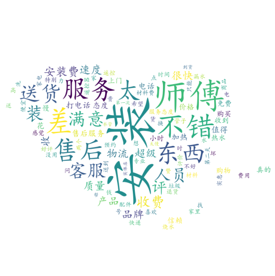

```python
font=r"./simkai.ttf"
backgroud_image=plt.imread('./hear4.jpg')
#生成词云对象
wordcloud_obj=WordCloud(font_path=font,
                       max_words=100,
                       background_color='white',
                       mask=backgroud_image)
#generate_from_frequencies:对应于已知词及对应的词频是多上，可以不进行分词统计
#cunter统计函数:作用在一个数组内，遍历所有元素，将每个元素出现的次数统计下来。
wordcloud_obj.generate_from_frequencies(Counter(review_long_clean.word.values))
plt.figure(figsize=(20,10))
#保存词云图
wordcloud_obj.to_file("商品评论分词后的(名词)词云图2.png")
plt.imshow(wordcloud_obj)
plt.axis('off')
plt.show
```

```
<wordcloud.wordcloud.WordCloud at 0x2652e8b8040>
```

```
<wordcloud.wordcloud.WordCloud at 0x2652e8b8040>
```

```
(-0.5, 623.5, 621.5, -0.5)
```

```
<function matplotlib.pyplot.show(close=None, block=None)>
```

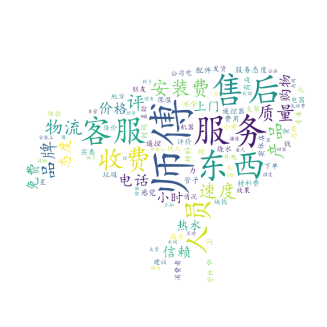

```python
#词云图二，名词词云图
font=r"./simkai.ttf"
backgroud_image=plt.imread('./jdicon.jpg')
#生成词云对象
wordcloud_obj=WordCloud(font_path=font,
                       max_words=100,
                       background_color='white',
                       mask=backgroud_image)
#generate_from_frequencies:对应于已知词及对应的词频是多上，可以不进行分词统计
#cunter统计函数:作用在一个数组内，遍历所有元素，将每个元素出现的次数统计下来。
wordcloud_obj.generate_from_frequencies(Counter(n_review_long_clean.word.values))
plt.figure(figsize=(20,10))
#保存词云图
wordcloud_obj.to_file("商品评论分词后的词云图1.png")
plt.imshow(wordcloud_obj)
plt.axis('off')
plt.show
```

从词云图可以看出，对评论数据进行预处理后，分词的效果较为符合预期，其中用户对“安装”、“师傅”、“售后”、“服务”等词出现的频率较多表示用户对这几个方面比较重视，所有作为商家要对这些方面要加强。

## 四、 基于决策树的情感分类

### （一）模型的构建，构造特征空间和标签

```python
review_long_clean
```

|  | index_content | word | nature | content_type | index_word |
| --- | --- | --- | --- | --- | --- |
| 0 | 1 | 东西 | ns | pos | 1 |
| 1 | 1 | 收到 | v | pos | 2 |
| 2 | 1 | 这么久 | r | pos | 3 |
| 5 | 1 | 忘 | v | pos | 4 |
| 8 | 1 | 好评 | v | pos | 5 |
| ... | ... | ... | ... | ... | ... |
| 63812 | 1999 | 差 | a | neg | 10 |
| 63815 | 2000 | 两个 | m | neg | 1 |
| 63817 | 2000 | 送到 | v | neg | 2 |
| 63823 | 2000 | 未 | d | neg | 3 |
| 63824 | 2000 | 送到 | v | neg | 4 |

25210 rows × 5 columns

```python
print(review_long_clean.index_content.unique())#统计行数
```

```
[   1    2    3 ... 1998 1999 2000]
```

```python
# 构造特征空间和标签
Y=[]
for ind in review_long_clean.index_content.unique():#统计行数
    y=[word for word in review_long_clean.content_type[review_long_clean.index_content==ind].unique()]
    Y.append(y)
print(len(Y))
```

```
1964
```

```python
X=[]
for ind in review_long_clean.index_content.unique():
    x=[word for word in review_long_clean.word[review_long_clean.index_content==ind].unique()]


    X.append(' '.join(x))
X
print(len(X))
```

[output not shown]

[output cut: 946 more lines]

[output not shown]

```
1964
```

### (二) 训练集、测试集的划分

```
sklearn 的train_test_split函数将矩阵随机划分为训练集和测试子集，并返回划分好的训练集样本和测试集标签
    X_train,X_test, y_train, y_test =sklearn.model_selection.train_test_split(train_data,train_target,test_size=0.4, random_state=0,stratify=y_train)
train_data：所要划分的样本特征集
 train_target：所要划分的样本结果
test_size：样本占比，如果是整数的话就是样本的数量、
 random_state：是随机数的种子。
随机数种子：其实就是该组随机数的编号，在需要重复试验的时候，保证得到一组一样的随机数。比如你每次都填1，其他参数一样的情况下你得到的随机数组是一样的。但填0或不填，每次都会不一样。
stratify是为了保持split前类的分布。比如有100个数据，80个属于A类，20个属于B类。如果train_test_split(... test_size=0.25, stratify = y_all), 那么split之后数据如下：
training: 75个数据，其中60个属于A类，15个属于B类。
testing: 25个数据，其中20个属于A类，5个属于B类。
```

```python
#第1步. 导入机器学习包
%pip install sklearn
from sklearn import tree
from sklearn.model_selection import train_test_split
from sklearn.feature_extraction.text import CountVectorizer
from sklearn.metrics import classification_report
from sklearn.metrics import accuracy_score
%pip install graphviz
import graphviz
```

```python
#第2步：词转向量，01矩阵
```

CountVectorizer是属于常见的特征数值计算类，是一个文本特征提取方法。对于每一个训练文本，它只考虑每种词汇在该训练文本中出现的频率。

CountVectorizer会将文本中的词语转换为词频矩阵，它通过fit_transform函数计算各个词语出现的次数。

```python
#第二步：训练集、测试集划分
x_train,x_test,y_train,y_test=train_test_split(X,Y,test_size=0.2,random_state=7)
x_train
x_test
```

[output not shown]

[output cut: 946 more lines]

[output not shown]

[output not shown]

[output cut: 338 more lines]

[output not shown]

```python
#第三步 生成一个特征计算类对象
count_vec=CountVectorizer(binary=True)
x_train=count_vec.fit_transform(x_train) #将训练集中的词语转换为词频矩阵
x_test=count_vec.transform(x_test)#将测试集词语转换为词频矩阵
x_train
x_test
```

```
<1571x3429 sparse matrix of type '<class 'numpy.int64'>'
	with 14253 stored elements in Compressed Sparse Row format>
```

```
<393x3429 sparse matrix of type '<class 'numpy.int64'>'
	with 3192 stored elements in Compressed Sparse Row format>
```

```python
#第四步 构建决策数
#生成一个决策树对象
dtc=tree.DecisionTreeClassifier(max_depth=5) #树深度：可以对这个参数可以调优，7，8，10
dtc.fit(x_train,y_train)
print('在训练集上的准确率:%.2f'%accuracy_score(y_train,dtc.predict(x_train)))

y_true=y_test
y_pred=dtc.predict(x_test)
print(classification_report(y_true,y_pred))
print('在测试集上的准确率:%.2f'%accuracy_score(y_true,y_pred))
```

```
DecisionTreeClassifier(max_depth=5)
```

```
在训练集上的准确率:0.72
              precision    recall  f1-score   support

         neg       0.63      0.96      0.76       197
         pos       0.92      0.44      0.60       196

    accuracy                           0.70       393
   macro avg       0.78      0.70      0.68       393
weighted avg       0.77      0.70      0.68       393

在测试集上的准确率:0.70
```

```python
dot_data=tree.export_graphviz(dtc,
                              out_file=None,
                              feature_names=count_vec.get_feature_names())
```

```python
graph=graphviz.Source(dot_data)
print(graph)
```

```
digraph Tree {
node [shape=box] ;
0 [label="不错 <= 0.5\ngini = 0.5\nsamples = 1571\nvalue = [790, 781]"] ;
1 [label="很快 <= 0.5\ngini = 0.49\nsamples = 1352\nvalue = [773, 579]"] ;
0 -> 1 [labeldistance=2.5, labelangle=45, headlabel="True"] ;
2 [label="信赖 <= 0.5\ngini = 0.48\nsamples = 1280\nvalue = [768, 512]"] ;
1 -> 2 ;
3 [label="实惠 <= 0.5\ngini = 0.469\nsamples = 1229\nvalue = [768, 461]"] ;
2 -> 3 ;
4 [label="放心 <= 0.5\ngini = 0.463\nsamples = 1207\nvalue = [767, 440]"] ;
3 -> 4 ;
5 [label="gini = 0.459\nsamples = 1191\nvalue = [767, 424]"] ;
4 -> 5 ;
6 [label="gini = 0.0\nsamples = 16\nvalue = [0, 16]"] ;
4 -> 6 ;
```

[output cut: 41 more lines]

```python
#第五步：画决策树，可以看到左边的样本比较多 samples=1280,1352
import os
cwd=os.getcwd()
dot_data=tree.export_graphviz(dtc
                              ,out_file=None
                              ,feature_names=count_vec.get_feature_names())
graph=graphviz.Source(dot_data)
graph.format='svg'
graph.render(cwd+'/tree',view=True)
graph
```

```
'E:\\教学资料\\基于电商产品评论数据情感分析week2\\tree.svg'
```

[figure not shown]